# Tek Değişkenli Zaman Serisi Analizi

Emircan ATALAY

## **Veri ve Metodoloji**

Bu çalışmada kullanılan veri, Türkiye İstatistik Kurumu (TÜİK) tarafından yayımlanan, 2015 (Haziran)-2023 (Aralık) yılları arasındaki tavuk yumurtası üretim miktarını (bin adet) kapsamaktadır. Veriler aylık olarak düzenlenmiş olup, toplamda 103 gözlemden oluşmaktadır. Veriler, trend, mevsimsellik ve rastgele bileşenlerden oluşan tipik bir zaman serisi yapısına sahiptir. Analiz sürecinde, öncelikle zaman serisinin genel görünümünü anlamak amacıyla bir zaman serisi grafiği oluşturulmuştur. Daha sonra, serinin otokorelasyon ve kısmi otokorelasyon fonksiyonları (ACF ve PACF) incelenerek serinin durağanlık durumu ve otoregresif yapısı analiz edilmiştir. Serinin durağan olmaması durumunda fark alma yöntemi uygulanarak durağanlık sağlanmıştır. Ayrıştırma modelleri, Regresyon modelleri(üstel regresyon, kübik regresyon, karesel regresyon, lojistik regresyon modelleri), Üstel düzleştirme yöntemleri(Winters yöntemleri), otoregresif modeller (AR, MA, ARMA, ARIMA) kullanılarak serinin yapısına en uygun model belirlenmiştir. Model seçimi sırasında Akaike Bilgi Kriteri (AIC) ve Bayes Bilgi Kriteri (BIC) , Ortalama Mutlak Hata (MAE), Ortalama Yüzde Hata (MAPE) gibi değerlendirme kriterleri göz önünde bulundurulmuştur.

## **Kütüphanelerin Yüklenmesi ve Verinin Aktarılması**

```r
library(fpp)
library(forecast)
library(haven)
library(stats)
library(ggplot2)
```

```r
veri = read_sav("veri.sav")
head(veri)
```

```
## # A tibble: 6 × 1
##   degerler
##      <dbl>
## 1  1198324
## 2  1286892
## 3  1294923
## 4  1340401
## 5  1417880
## 6  1408095
```

```r
summary(veri)
```

```
##     degerler
##  Min.   :1198324
##  1st Qu.:1558174
##  Median :1617495
##  Mean   :1610287
##  3rd Qu.:1689308
##  Max.   :1855505
```

## **Zaman Serisi, ACF ve PACF Grafikleri**

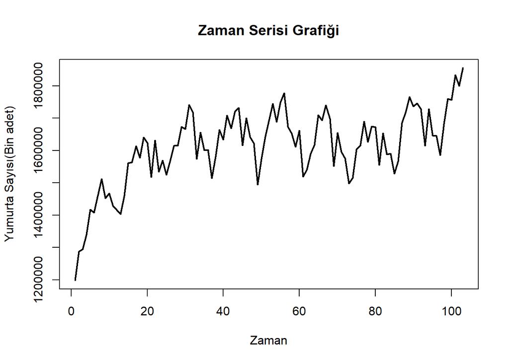

```r
veri_ts = ts(veri)

ts.plot(veri_ts,gpars=list(xlab="Zaman", ylab="Yumurta Sayısı(Bin adet)",main= "Zaman Serisi Grafiği",lwd=2))
```

Zaman serisi grafiği incelendiğinde, genel olarak bir artış eğiliminin olduğu gözlemlenmektedir. Ayrıca, belirli aralıklarla artış ve azalışların meydana gelmesi, serinin hem mevsimsel dalgalanmalara hem de uzun vadeli bir trende sahip olabileceğini düşündürmektedir.

Serinin geçmiş değerleri ile olan ilişkilerini daha net bir şekilde gözlemleyebilmek ve mevsimsel ile trend bileşenleri hakkında daha güçlü çıkarımlar yapabilmek adına ACF (Autocorrelation Function) ve PACF (Partial Autocorrelation Function) grafikleri incelenecektir.

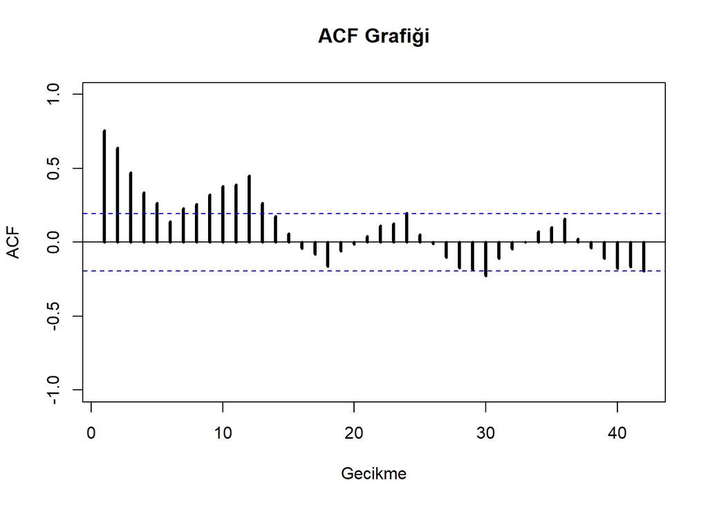

```r
Acf(veri_ts,lag.max = 42,  ylim=c(-1,1), lwd=3, main = "ACF Grafiği", xlab="Gecikme")
```

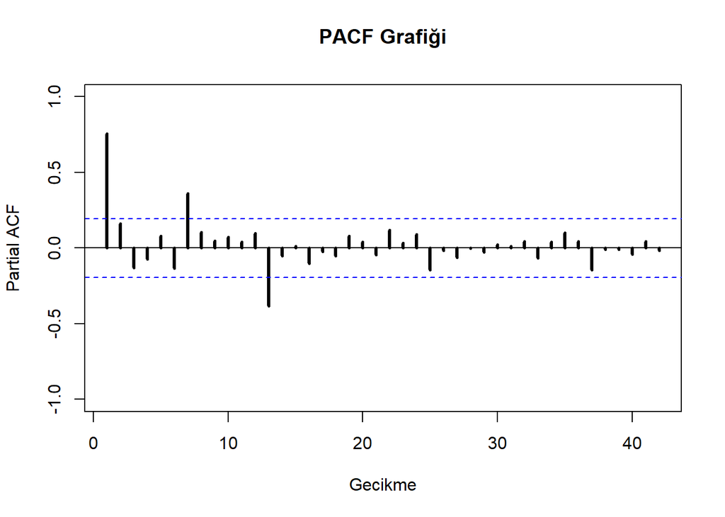

```r
Pacf(veri_ts,lag.max = 42, ylim=c(-1,1), lwd=3, main = "PACF Grafiği", xlab="Gecikme")
```

Trend mevcut olduğu için seriyi durağan hale getirmek adına fark alma yöntemi kullanılacaktır ve fark alınmış serinin ACF grafiği tekrar incelenecektir.

### **Farkı Alınmış Seri**

```r
veri_trend = diff(veri_ts)
```

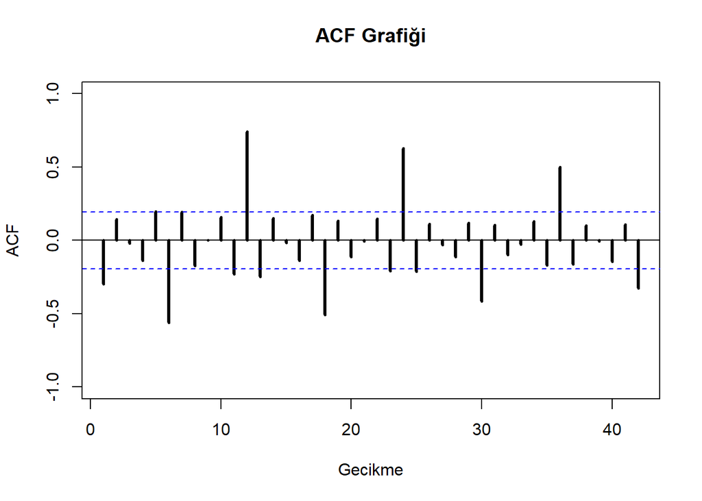

```r
Acf(veri_trend,lag.max = 42,  ylim=c(-1,1), lwd=3, main = "ACF Grafiği", xlab="Gecikme")
```

Belirli aralıklarla sınırların dışına çıkan gecikme değerleri göz önünde bulundurularak, periyot belirlenip mevsimsel fark alınarak seri mevsimsellikten arındırılacak ve durağan hale getirilecektir.

Periyot belirlenirken, sırasıyla sınır dışına çıkan en büyük gecikme değeri ile ikinci en büyük gecikme değeri arasındaki gecikmelerin sayısı göz önünde bulundurulmuş ve periyot 12 olarak belirlenmiştir.

```r
veri_mevsimsel = diff(veri_trend, lag = 12)
```

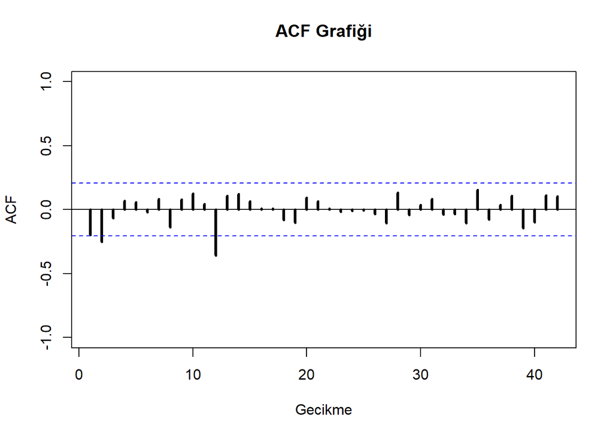

```r
Acf(veri_mevsimsel,lag.max = 42,  ylim=c(-1,1), lwd=3, main = "ACF Grafiği", xlab="Gecikme")
```

Farkı alınmış serinin ACF grafiği yukarıda verilmiştir. Grafiğe bakıldığında, serinin trend ve mevsimsellikten arındırıldığı ve böylece durağan hale geldiği gözlemlenmektedir.

Serinin durağan hale getirilmesinin ardından, uygun bir model seçebilmek için çeşitli yöntemler uygulanacaktır. Bu süreçte farklı modelleme yöntemleri, serinin yapısına en iyi uyum sağlayacak modelin belirlenmesi amacıyla değerlendirilecektir. Analiz sonuçları, model seçiminin doğruluğunu destekleyen kriterler ve görsellerle detaylı şekilde sunulacaktır.

## **Toplamsal Winters Yöntemi**

```r
veri_ts2 = ts(veri, start = c(2015,6), frequency = 12)
```

```r
Winters1 = ets(veri_ts2, model = "AAA")

summary(Winters1)
```

```
## ETS(A,Ad,A)
##
## Call:
## ets(y = veri_ts2, model = "AAA")
##
##   Smoothing parameters:
##     alpha = 0.7359
##     beta  = 1e-04
##     gamma = 1e-04
##     phi   = 0.9672
##
##   Initial states:
##     l = 1378314.9342
##     b = 13232.1117
##     s = -38687.45 -38690.9 27470.19 -41285.48 76430.04 83399.3
##            36746.94 74711.9 13537.23 2058.913 -72053.65 -123637.1
##
##   sigma:  30116.37
##
##      AIC     AICc      BIC
## 2619.240 2627.382 2666.665
##
## Training set error measures:
##                    ME     RMSE      MAE         MPE     MAPE      MASE
## Training set 182.5407 27519.04 20413.43 -0.02101148 1.297803 0.3224222
##                    ACF1
## Training set 0.04697417
```

Kullanılan veri kümesine gerekli düzeltmeler yapıldıktan sonra Toplamsal Winters yöntemi uygulandığında testin özet sonuçları yukarıdaki gibidir.

Modelin uygunluğunu kontrol etmek için ilk olarak orijinal seri ile tahmin serisinin uyumu incelenecektir.

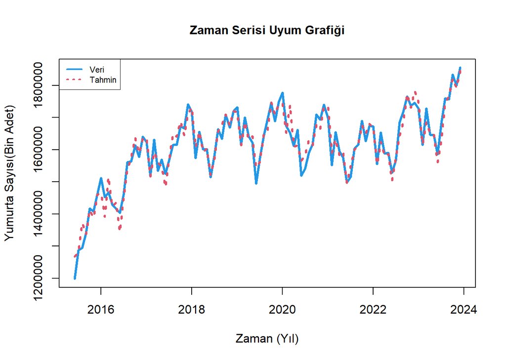

```r
tahmint = Winters1[["fitted"]]

plot(window(veri_ts2), main = "Zaman Serisi Uyum Grafiği",
      xlab="Zaman (Yıl)", ylab="Yumurta Sayısı(Bin Adet)",lty=1, col=4, lwd=3,ylim=c(min(veri_ts2), max(veri_ts2)),
      cex.main = 1)
lines( window(tahmint) ,lty=3,col=2,lwd=3)
legend("topleft",c(expression(paste(Veri)),
               expression(paste(Tahmin))),
       lwd=c(2,2),lty=c(1,3), cex=0.7, col=c(4,2),box.lwd = 0.5)
```

Grafik incelendiğinde, orijinal seri ile tahmin serisinin yeteri kadar uyum içerisinde olduğu söylenebilir.

Artıkların, model varsayımlarına uygunluğunu incelerken genellikle kullanılan üç temel grafik bulunmaktadır. ACF Grafiği, Artıkların Zaman Grafiği ve Artıkların Dağılım Grafiği. Bu grafikler incelenecek ve Box-Ljung testi uygulanacaktır.

```r
hata = Winters1[["residuals"]]
```

### **Box-Ljung Test**

$H_0$ : Gecikmeler arasında ilişki yoktur.

$H_1$ : Gecikmeler arasında ilişki vardır.

```r
Box.test (hata, lag = 42, type = "Ljung")
```

```
##
##  Box-Ljung test
##
## data:  hata
## X-squared = 35.025, df = 42, p-value = 0.7685
```

Test sonucunda, p-value > 0.05 olduğundan dolayı $H_0$ **REDDEDİLEMEZ.** Yani gecikmeler arasında ilişki olmadığı söylenebilir.

### **Hata serisinin ACF grafiği**

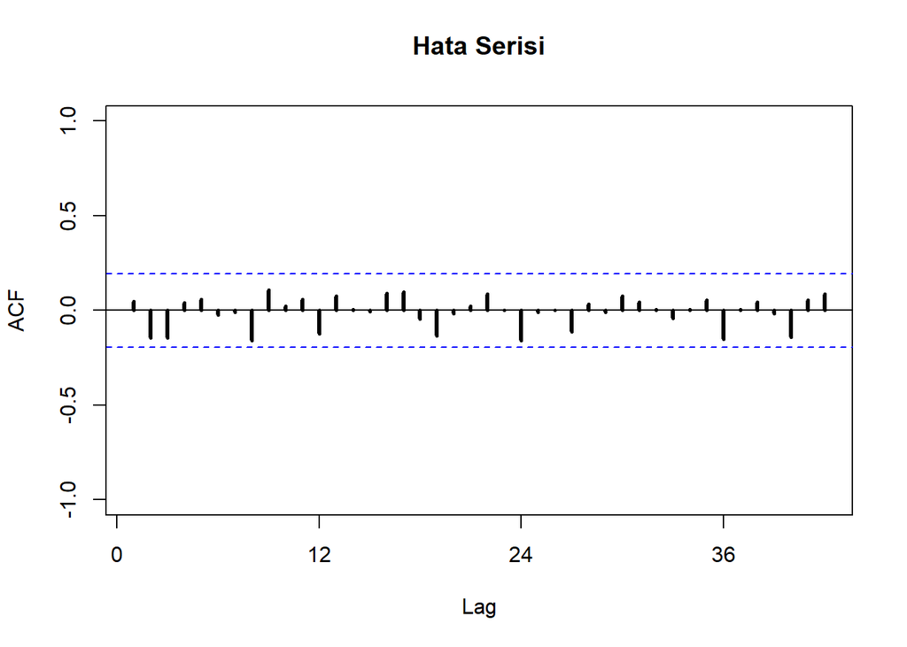

```r
Acf(hata,main="Hata Serisi", lag.max = 42,  ylim=c(-1,1), lwd=3)
```

Grafikte görüldüğü üzere, gecikmeler sınırların içerisinde olduğu için hata serisi, akgürültü serisidir.

Box-Ljung testi sonucunda da gecikmeler arasında ilişki olmadığını söylemiştik. İncelediğimiz ACF grafiğinde de hata serisinin akgürültü serisi olduğu anlaşılmıştır.

### **Artıkların Zaman Serisi Grafiği ve Dağılım Grafiği**

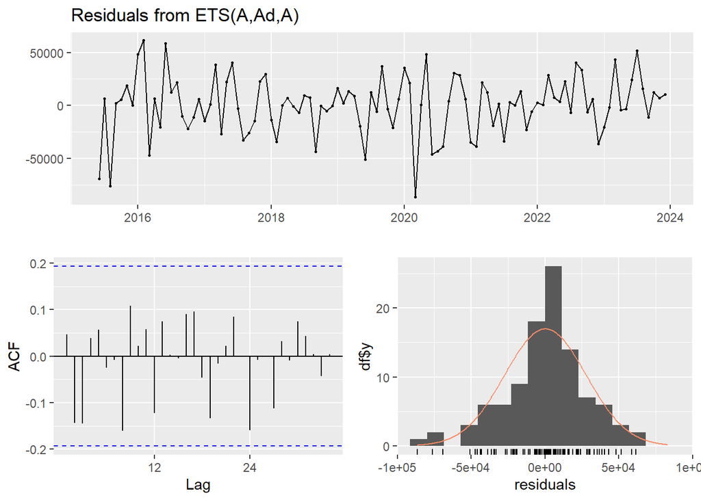

```
##
##  Ljung-Box test
##
## data:  Residuals from ETS(A,Ad,A)
## Q* = 35.025, df = 42, p-value = 0.7685
##
## Model df: 0.   Total lags used: 42
```

```r
checkresiduals(Winters1, lag = 42)
```

Residuals from ETS grafiği incelendiğinde, artıkların belirgin bir trend, mevsimsellik veya yapı göstermediği bu sebeple rastgele bir şekilde dağılmış olduğu söylenebilir. Bu istenilen bir durumdur.

Artıkların dağılım grafiğinde, artıkların dağılımının normal dağılıma uyumlu olması beklenir.Yukarıdaki grafik incelendiğinde, artıkların dağılımının ,neredeyse, normal dağılıma uyumlu olduğu söylenebilir.

Tüm bu gerekçeler doğrultusunda, modelin uygun bir yapıya sahip olduğu söylenebilir. Bu uygunluk temelinde, model kullanılarak sonraki 12 ay için tahminler gerçekleştirilecektir.

### **Tahmin Değerleri**

```r
ongoru = forecast(Winters1,h=12)

ongoru[["mean"]]
```

```
##          Jan     Feb     Mar     Apr     May     Jun     Jul     Aug     Sep
## 2024 1846160 1728852 1798002 1732222 1732595 1647998 1699930 1774369 1786176
##          Oct     Nov     Dec
## 2024 1847666 1810003 1856947
```

```r
ongoru
```

```
##          Point Forecast   Lo 80   Hi 80   Lo 95   Hi 95
## Jan 2024        1846160 1807565 1884756 1787133 1905187
## Feb 2024        1728852 1680929 1776775 1655560 1802144
## Mar 2024        1798002 1742290 1853715 1712797 1883207
## Apr 2024        1732222 1669682 1794763 1636575 1827870
## May 2024        1732595 1663901 1801289 1627536 1837654
## Jun 2024        1647998 1573657 1722340 1534302 1761694
## Jul 2024        1699930 1620339 1779521 1578207 1821654
## Aug 2024        1774369 1689854 1858885 1645114 1903624
## Sep 2024        1786176 1697006 1875345 1649803 1922548
## Oct 2024        1847666 1754073 1941259 1704527 1990804
## Nov 2024        1810003 1712186 1907821 1660404 1959603
## Dec 2024        1856947 1755079 1958815 1701154 2012741
```

Model kullanılarak yapılan tahminlerin %80 güven düzeyindeki alt sınırı (Lo80), üst sınırı (Hi80), %95 güven düzeyindeki alt sınırı (Lo95), üst sınırı (Hi95) ve nokta tahmin değerleri yukarıda sunulmuştur.

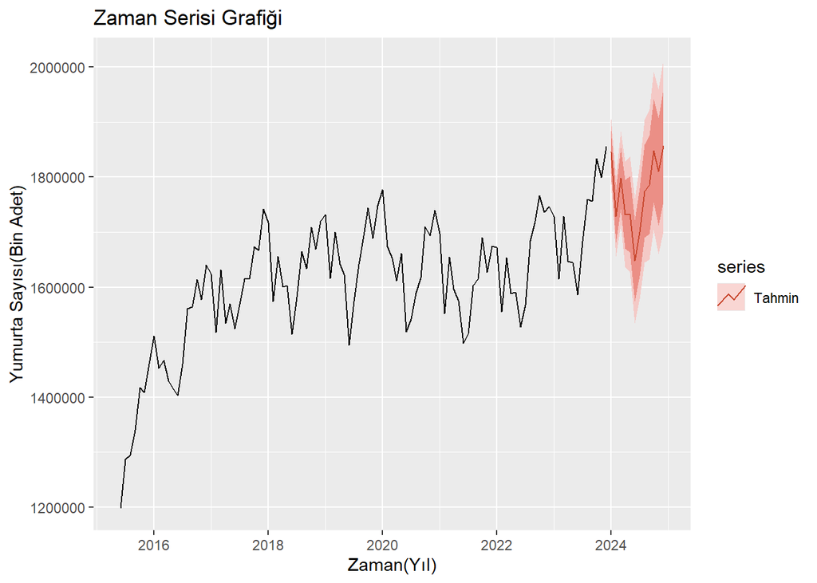

```r
autoplot(veri_ts2) +
  autolayer(ongoru, series = "Tahmin", PI=TRUE) +
  ggtitle("Zaman Serisi Grafiği") +
  xlab("Zaman(Yıl)") +
  ylab("Yumurta Sayısı(Bin Adet)")
```

## **Çarpımsal Winters Yöntemi**

```r
Winters2 = ets(abs(veri_ts2), model = "MAM")

summary(Winters2)
```

```
## ETS(M,Ad,M)
##
## Call:
## ets(y = abs(veri_ts2), model = "MAM")
##
##   Smoothing parameters:
##     alpha = 0.692
##     beta  = 2e-04
##     gamma = 1e-04
##     phi   = 0.9778
##
##   Initial states:
##     l = 1362314.9923
##     b = 13415.5565
##     s = 0.9771 0.9761 1.0169 0.9743 1.0466 1.0506
##            1.0223 1.0457 1.0075 1.0003 0.9587 0.9239
##
##   sigma:  0.0189
##
##      AIC     AICc      BIC
## 2621.452 2629.595 2668.878
##
## Training set error measures:
##                     ME     RMSE      MAE        MPE     MAPE      MASE
## Training set -1764.553 26933.01 20425.78 -0.1387963 1.297466 0.3226173
##                    ACF1
## Training set 0.07260807
```

Kullanılan veri kümesine gerekli düzeltmeler yapıldıktan sonra **Çarpımsal Winters** yöntemi uygulandığında testin özet sonuçları yukarıdaki gibidir.

Modelin uygunluğunu kontrol etmek için ilk olarak orijinal seri ile tahmin serisinin uyumu incelenecektir.

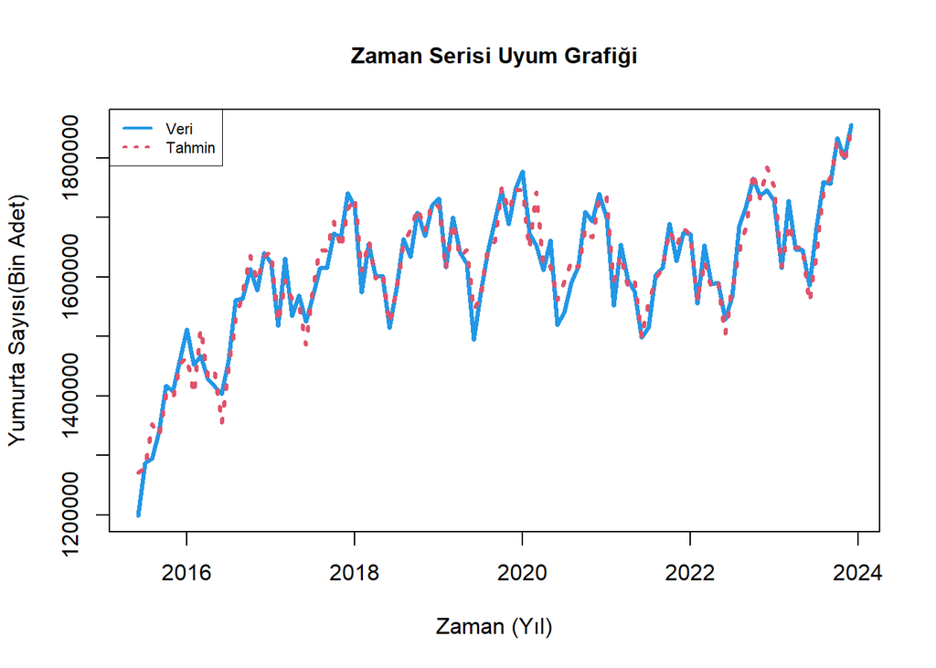

```r
tahmin1 = Winters2[["fitted"]]

plot(window(veri_ts2), main = "Zaman Serisi Uyum Grafiği",
      xlab="Zaman (Yıl)", ylab="Yumurta Sayısı(Bin Adet)",lty=1, col=4, lwd=3,ylim=c(min(veri_ts2), max(veri_ts2)),
      cex.main = 1)
lines( window(tahmin1) ,lty=3,col=2,lwd=3)
legend("topleft",c(expression(paste(Veri)),
               expression(paste(Tahmin))),
       lwd=c(2,2),lty=c(1,3), cex=0.7, col=c(4,2),box.lwd = 0.5)
```

Grafik incelendiğinde, orijinal seri ile tahmin serisinin yeteri kadar uyum içerisinde olduğu söylenebilir.

Artıkların, model varsayımlarına uygunluğunu incelerken genellikle kullanılan üç temel grafik bulunmaktadır. ACF Grafiği, Artıkların Zaman Grafiği ve Artıkların Dağılım Grafiği. Bu grafikler incelenecek ve Box-Ljung testi uygulanacaktır.

```r
hata1<- Winters2[["residuals"]]
```

### **Box-Ljung Test**

$H_0$ : Gecikmeler arasında ilişki yoktur.

$H_1$ : Gecikmeler arasında ilişki vardır.

```r
Box.test (hata1, lag = 42, type = "Ljung")
```

```
##
##  Box-Ljung test
##
## data:  hata1
## X-squared = 31.927, df = 42, p-value = 0.8702
```

Test sonucunda, p-value > 0.05 olduğundan dolayı $H_0$ **REDDEDİLEMEZ.** Yani gecikmeler arasında ilişki olmadığı söylenebilir.